# Least Squares Solution for Inconsistent Systems

Author

Nathan Lunceford

## Overview

The least squares solution minimizes the distance between the vector $\mathbf{b}$ and the column space of $A$. The column space of $A$, denoted $\mathrm{Col}(A)$, is equivalent to the span of the columns of $A$, written as $\mathrm{span}(A_1, A_2, \dots, A_n)$, where $A_1, A_2, \dots, A_n$ are the columns of $A$.

This distance corresponds to the residual $\|\mathbf{b} - \mathbf{\hat{b}}\|$, where $\mathbf{\hat{b}} = A\mathbf{\hat{x}}$ is the projection of $\mathbf{b}$ onto $\mathrm{Col}(A)$.

## **Visualizing the Least Squares Solution**

The figure below illustrates how the least squares solution $\mathbf{\hat{x}}$ projects $\mathbf{b}$ onto $\mathrm{Col}(A)$, which is spanned by the columns of $A$. The vector $\mathbf{r} = \mathbf{b} - \mathbf{\hat{b}}$ is orthogonal to $\mathrm{Col}(A)$.

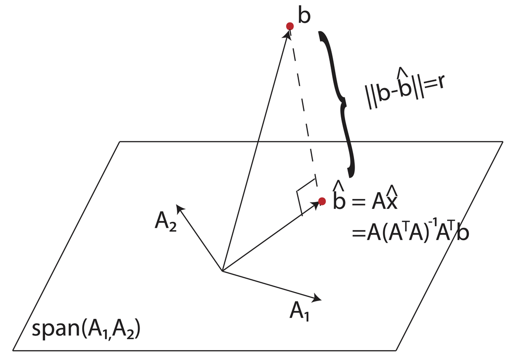

- **$\mathbf{b}$**: The target vector outside $\mathrm{Col}(A)$.
- **$\mathbf{\hat{b}}$**: The projection of $\mathbf{b}$ onto $\mathrm{Col}(A)$, calculated as $\mathbf{\hat{b}} = A(A^\top A)^{-1}A^\top \mathbf{b}$.
- **$\mathbf{r}$**: The residual vector, orthogonal to $\mathrm{Col}(A)$.
- **$A_1, A_2, \dots, A_n$**: Basis vectors spanning $\mathrm{Col}(A)$.

## Intuitive Walkthrough of the Proof

### 1. **The Problem**

Given a matrix $A$ with columns $A_1, A_2, \dots, A_n$ and a vector $\mathbf{b}$, the system $A\mathbf{x} = \mathbf{b}$ is inconsistent if $\mathbf{b}$ does not lie in $\mathrm{Col}(A)$. The objective is to find $\mathbf{\hat{x}}$, which minimizes the distance between $\mathbf{b}$ and $\mathrm{Col}(A)$.

### 2. **Projection and Residual**

Minimizing the distance involves projecting $\mathbf{b}$ onto $\mathrm{Col}(A)$. The projection is denoted $\mathbf{\hat{b}} = A\mathbf{\hat{x}}$. The residual $\mathbf{r} = \mathbf{b} - \mathbf{\hat{b}}$ represents the difference, and the goal is to minimize $\|\mathbf{r}\|^2$, which can be written as:

$$\|\mathbf{r}\|^2 = \|\mathbf{b} - A\mathbf{\hat{x}}\|^2.$$

### 3. **Orthogonality Condition**

The residual $\mathbf{r}$ is orthogonal to $\mathrm{Col}(A)$ when $\mathbf{\hat{b}}$ is the best approximation of $\mathbf{b}$. This condition is expressed as:

$$A^\top \mathbf{r} = 0 \quad \text{or equivalently} \quad A^\top (\mathbf{b} - A\mathbf{\hat{x}}) = 0.$$

### 4. **Normal Equations**

Expanding the orthogonality condition yields:

$$A^\top \mathbf{b} - A^\top A\mathbf{\hat{x}} = 0 \quad \Rightarrow \quad A^\top A\mathbf{\hat{x}} = A^\top \mathbf{b}.$$

This is the **normal equation**. Solving it provides $\mathbf{\hat{x}}$, the least squares solution.

### 5. **Computing $\mathbf{\hat{x}}$**

If $A^\top A$ is invertible, the solution for $\mathbf{\hat{x}}$ is:

$$\mathbf{\hat{x}} = (A^\top A)^{-1}A^\top \mathbf{b}.$$

### 6. **Geometric Interpretation**

The projection $\mathbf{\hat{b}}$ lies in $\mathrm{Col}(A)$, and the residual $\mathbf{r} = \mathbf{b} - \mathbf{\hat{b}}$ is orthogonal to this space. This makes $\mathbf{\hat{b}}$ the closest vector in $\mathrm{Col}(A)$ to $\mathbf{b}$.

## **Summary**

The least squares method projects $\mathbf{b}$ onto $\mathrm{Col}(A)$, solving the equation:

$$A^\top A\mathbf{\hat{x}} = A^\top \mathbf{b}.$$

The solution is:

$$\mathbf{\hat{x}} = (A^\top A)^{-1}A^\top \mathbf{b}.$$

This projection minimizes the residual $\|\mathbf{b} - \mathbf{\hat{b}}\|$, making it the best approximation of $\mathbf{b}$ within $\mathrm{Col}(A)$. The accompanying diagram visually demonstrates this projection and the orthogonal residual.